# Forest Fire Area Prediction

## Using a few ML algorithms, predict the area of a forest fire based on meteorological conditions, per the data set (https://archive.ics.uci.edu/ml/datasets/forest+fires) and approach outlined in [Cortez and Morais, 2007] P. Cortez and A. Morais. A Data Mining Approach to Predict Forest Fires using Meteorological Data.

### Compare the efficiency, error, and accuracy of each algorithm employed

### set working directory and load needed packages

```r
knitr::opts_knit$set(root.dir = 'C:/Users/tscott/')
```

```r
# load packages
library(tidyverse) #for ggplot and dplyr
library(corrplot) #for correlation plots
```

### Get the data

Pre-downloaded from https://archive.ics.uci.edu/ml/datasets/forest+fires

```r
forestRaw <- read.csv("./OneDrive - Eastside Preparatory School/Courses/DataScience_2/data/forestfires.csv")
```

### From the documentation for the data set

Attribute information:

For more information, read [Cortez and Morais, 2007].

1. X - x-axis spatial coordinate within the Montesinho park map: 1 to 9
2. Y - y-axis spatial coordinate within the Montesinho park map: 2 to 9
3. month - month of the year: “jan” to “dec”
4. day - day of the week: “mon” to “sun”
5. FFMC - FFMC index from the FWI system: 18.7 to 96.20
6. DMC - DMC index from the FWI system: 1.1 to 291.3
7. DC - DC index from the FWI system: 7.9 to 860.6
8. ISI - ISI index from the FWI system: 0.0 to 56.10
9. temp - temperature in Celsius degrees: 2.2 to 33.30
10. RH - relative humidity in %: 15.0 to 100
11. wind - wind speed in km/h: 0.40 to 9.40
12. rain - outside rain in mm/m2 : 0.0 to 6.4
13. area - the burned area of the forest (in ha): 0.00 to 1090.84 (this output variable is very skewed towards 0.0, thus it may make sense to model with the logarithm transform).

Need to watch out for correlations, e.g., the Initial Spread Index (ISI) is a numeric rating of the expected rate of fire spread. It is based on wind speed and FFMC.

More deets: https://wikifire.wsl.ch/tiki-indexbdbc.html?page=Canadian+forest+fire+weather+index+system

### Inspect it and check for correlations

```r
summary(forestRaw)
```

```
##        X               Y          month               day
##  Min.   :1.000   Min.   :2.0   Length:517         Length:517
##  1st Qu.:3.000   1st Qu.:4.0   Class :character   Class :character
##  Median :4.000   Median :4.0   Mode  :character   Mode  :character
##  Mean   :4.669   Mean   :4.3
##  3rd Qu.:7.000   3rd Qu.:5.0
##  Max.   :9.000   Max.   :9.0
##       FFMC            DMC              DC             ISI
##  Min.   :18.70   Min.   :  1.1   Min.   :  7.9   Min.   : 0.000
##  1st Qu.:90.20   1st Qu.: 68.6   1st Qu.:437.7   1st Qu.: 6.500
##  Median :91.60   Median :108.3   Median :664.2   Median : 8.400
##  Mean   :90.64   Mean   :110.9   Mean   :547.9   Mean   : 9.022
##  3rd Qu.:92.90   3rd Qu.:142.4   3rd Qu.:713.9   3rd Qu.:10.800
##  Max.   :96.20   Max.   :291.3   Max.   :860.6   Max.   :56.100
##       temp             RH              wind            rain
##  Min.   : 2.20   Min.   : 15.00   Min.   :0.400   Min.   :0.00000
##  1st Qu.:15.50   1st Qu.: 33.00   1st Qu.:2.700   1st Qu.:0.00000
##  Median :19.30   Median : 42.00   Median :4.000   Median :0.00000
##  Mean   :18.89   Mean   : 44.29   Mean   :4.018   Mean   :0.02166
##  3rd Qu.:22.80   3rd Qu.: 53.00   3rd Qu.:4.900   3rd Qu.:0.00000
##  Max.   :33.30   Max.   :100.00   Max.   :9.400   Max.   :6.40000
##       area
##  Min.   :   0.00
##  1st Qu.:   0.00
##  Median :   0.52
##  Mean   :  12.85
##  3rd Qu.:   6.57
##  Max.   :1090.84
```

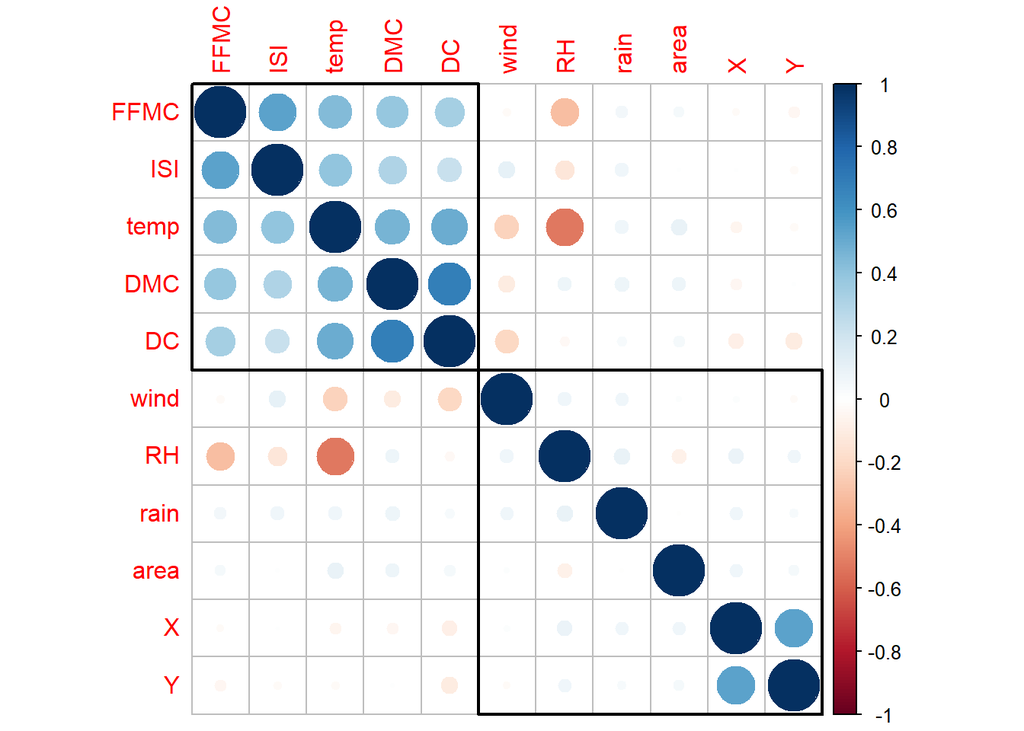

```r
# might want to set the month and day to factors
# but for correlation we can only use numeric values

forestNum <- forestRaw %>% select(-month, -day)
corrs <- cor(forestNum)
corrplot(corrs, order = 'hclust', addrect = 2)
```

### Quite a bit of correlation, especially between temp and the FWI values. Note that there are NO strong correlations with our goal, area

### Having variables that correlate strongly can both make your model worse and make it prone to overfitting - training well on the train data and poor performance on anything else

### When you read the paper by the authors [Cortez and Morais, 2007], you’ll notice they took

$ln(area + 1)$

### (area + 1 to avoid log of zero) so the range wasn’t so high. Let’s do that. But we have to remember to do

$e^x-1$ afterward to get back to actual area

```r
forestNum <- forestNum %>% mutate(logArea = log(area+1))
summary(forestNum)
```

```
##        X               Y            FFMC            DMC              DC
##  Min.   :1.000   Min.   :2.0   Min.   :18.70   Min.   :  1.1   Min.   :  7.9
##  1st Qu.:3.000   1st Qu.:4.0   1st Qu.:90.20   1st Qu.: 68.6   1st Qu.:437.7
##  Median :4.000   Median :4.0   Median :91.60   Median :108.3   Median :664.2
##  Mean   :4.669   Mean   :4.3   Mean   :90.64   Mean   :110.9   Mean   :547.9
##  3rd Qu.:7.000   3rd Qu.:5.0   3rd Qu.:92.90   3rd Qu.:142.4   3rd Qu.:713.9
##  Max.   :9.000   Max.   :9.0   Max.   :96.20   Max.   :291.3   Max.   :860.6
##       ISI              temp             RH              wind
##  Min.   : 0.000   Min.   : 2.20   Min.   : 15.00   Min.   :0.400
##  1st Qu.: 6.500   1st Qu.:15.50   1st Qu.: 33.00   1st Qu.:2.700
##  Median : 8.400   Median :19.30   Median : 42.00   Median :4.000
##  Mean   : 9.022   Mean   :18.89   Mean   : 44.29   Mean   :4.018
##  3rd Qu.:10.800   3rd Qu.:22.80   3rd Qu.: 53.00   3rd Qu.:4.900
##  Max.   :56.100   Max.   :33.30   Max.   :100.00   Max.   :9.400
##       rain              area            logArea
##  Min.   :0.00000   Min.   :   0.00   Min.   :0.0000
##  1st Qu.:0.00000   1st Qu.:   0.00   1st Qu.:0.0000
##  Median :0.00000   Median :   0.52   Median :0.4187
##  Mean   :0.02166   Mean   :  12.85   Mean   :1.1110
##  3rd Qu.:0.00000   3rd Qu.:   6.57   3rd Qu.:2.0242
##  Max.   :6.40000   Max.   :1090.84   Max.   :6.9956
```

## multi-linear regression

### We’ll naively try with all the numeric values. We’re doing no normalization and not removing any that correlate with others, so we don’t expect a great result.

```r
# We're going to use 80% of the rows to train the model
# then test it out on the remaining 20% of the data

# Create Training and Test data -
set.seed(732)  # setting seed to reproduce results of random sampling

# create row indices for training data
# sample will choose random row numbers (80% of the total number of rows)
trainingRowIndex <- sample(1:nrow(forestNum), 0.8*nrow(forestNum))

# use those row numbers to split up the data into rows for training
# and rows for testing

# model training data are the rows that sample identified above
trainingData <- forestNum[trainingRowIndex, ]

# model test data are the remaining rows
# the minus sign says  to take "all rows but those in trainingRowIndex"
testData  <- forestNum[-trainingRowIndex, ]

# make the model
# remember to use the logArea outcome rather than area
mlrModel <- lm(data=trainingData, logArea ~ .-area)
summary(mlrModel)
```

```
##
## Call:
## lm(formula = logArea ~ . - area, data = trainingData)
##
## Residuals:
##     Min      1Q  Median      3Q     Max
## -1.7753 -1.0993 -0.5617  0.9186  4.9326
##
## Coefficients:
##               Estimate Std. Error t value Pr(>|t|)
## (Intercept) -0.4178970  1.9960909  -0.209   0.8343
## X            0.0489166  0.0356835   1.371   0.1712
## Y           -0.0283504  0.0674614  -0.420   0.6745
## FFMC         0.0130635  0.0213910   0.611   0.5417
## DMC          0.0023941  0.0016680   1.435   0.1520
## DC           0.0001185  0.0004079   0.291   0.7715
## ISI         -0.0246378  0.0189891  -1.297   0.1952
## temp         0.0028349  0.0199384   0.142   0.8870
## RH          -0.0048908  0.0060966  -0.802   0.4229
## wind         0.0863988  0.0420753   2.053   0.0407 *
## rain         0.0749754  0.2168086   0.346   0.7297
## ---
## Signif. codes:  0 '***' 0.001 '**' 0.01 '*' 0.05 '.' 0.1 ' ' 1
##
## Residual standard error: 1.403 on 402 degrees of freedom
## Multiple R-squared:  0.03041,    Adjusted R-squared:  0.006288
## F-statistic: 1.261 on 10 and 402 DF,  p-value: 0.2508
```

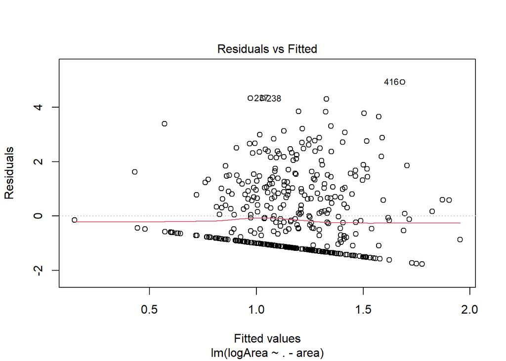

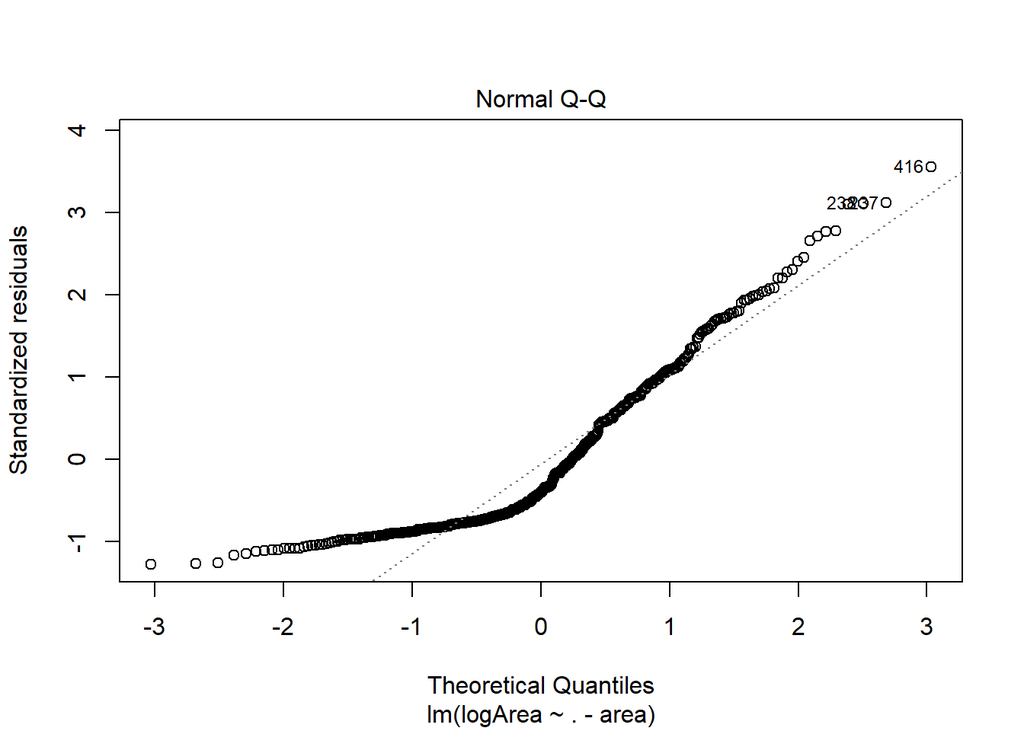

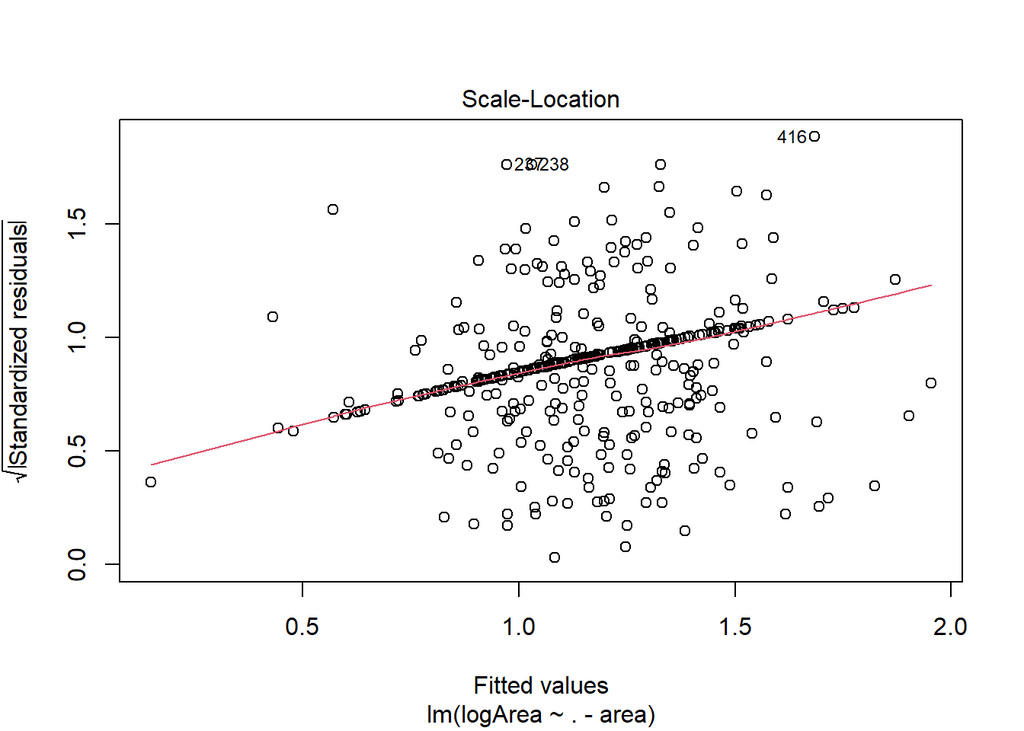

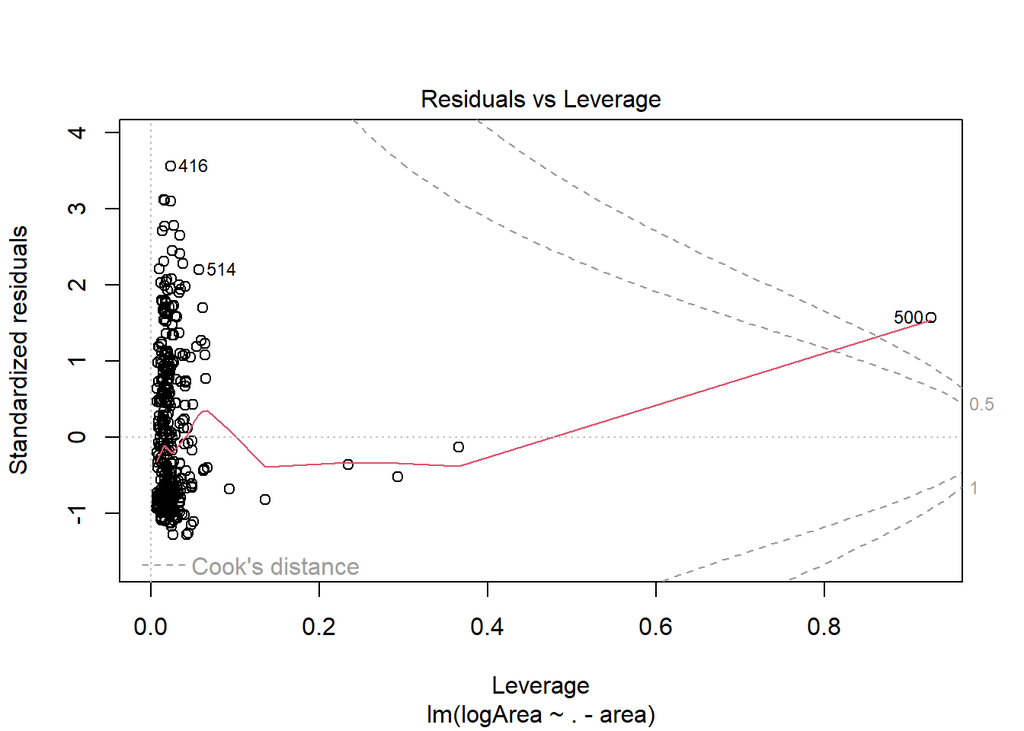

```r
# Q-Q plot is a test for normally distributed residuals (2nd plot in the sequence)
# should be on a 45 deg line with little deviation
plot(mlrModel)
```

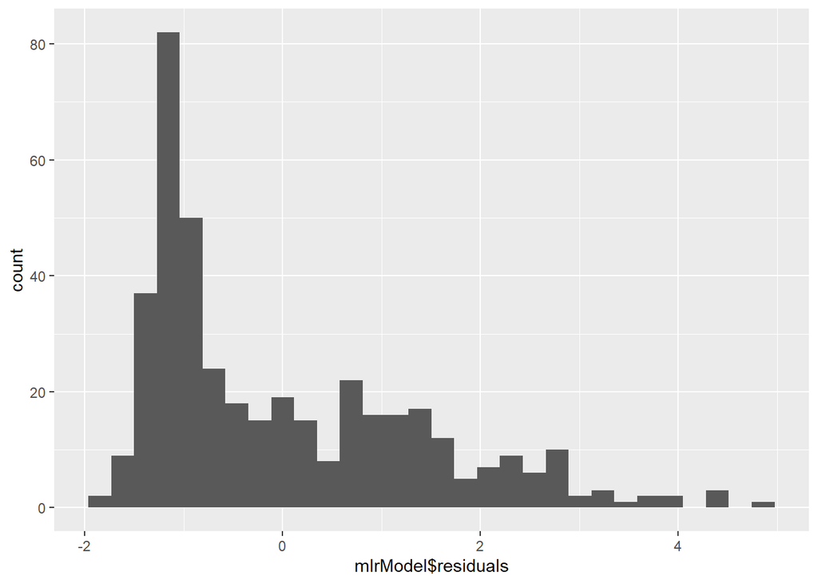

```r
# histogram shows us something similar
ggplot(data=mlrModel, aes(x=mlrModel$residuals)) + geom_histogram()
```

## Finally, let’s look at our main measure of goodness we’ll be using, the RMSE (root mean squared error)

$RMSE = \sqrt{\frac{\sum(\hat{y}_i - y_i)^2}{n}}$

```r
# get values the model predicts for the test set
predictedArea <- predict(mlrModel, newdata=testData)

# calculation root mean squared error
(rmse_mlr <- sqrt(mean((predictedArea - testData$logArea) ^ 2, na.rm = TRUE)))
```

```
## [1] 1.377032
```

### We’ll need that many times, so let’s make an RMSE function to use

```r
myRMSE <- function(pred, obs) {
  return(sqrt(mean((pred - obs) ^ 2, na.rm = TRUE)))
}


# make sure it works
myRMSE(predictedArea,testData$logArea )
```

```
## [1] 1.377032
```

### Note that this is the error for the natural logged data and it still really sucks - we’re way off of a decent model (which we might have predicted from the high median residuals and terrible stats)

## Do we give up? Heck no! There are other algorithms!

## Decision Tree

```r
# packages for decision trees
#install.packages(c("rpart","rpart.plot","rattle"))
library(rpart)
library(rpart.plot)
library(RColorBrewer)
library(rattle)
# build the tree
start1 <- Sys.time()
myTree <- rpart(data=trainingData, logArea ~ .-area, method='anova')
end1 <- Sys.time()          # Finishing time
(time1 <- end1 - start1) # total time
```

```
## Time difference of 0.02200103 secs
```

```r
# check it out and plot the tree
#plot(myTree)
#text(myTree,pretty=0)
summary(myTree)
```

```
## Call:
## rpart(formula = logArea ~ . - area, data = trainingData, method = "anova")
##   n= 413
##
##            CP nsplit rel error   xerror       xstd
## 1  0.02246242      0 1.0000000 1.008139 0.07769285
## 2  0.02236346      1 0.9775376 1.050428 0.07981928
## 3  0.01893917      2 0.9551741 1.073098 0.08107304
## 4  0.01763564      5 0.8978239 1.126865 0.08894216
## 5  0.01762558      6 0.8801882 1.134344 0.08911857
## 6  0.01533431      7 0.8625627 1.186233 0.08980312
## 7  0.01383583      8 0.8472283 1.220325 0.09167561
## 8  0.01353482     11 0.8057208 1.231776 0.09204576
## 9  0.01219311     12 0.7921860 1.250810 0.09334249
## 10 0.01184207     13 0.7799929 1.262736 0.09386906
## 11 0.01087515     14 0.7681508 1.255557 0.09392397
## 12 0.01009564     15 0.7572757 1.248570 0.09422280
## 13 0.01000000     16 0.7471800 1.250988 0.09295809
##
## Variable importance
## temp   RH    X  ISI FFMC  DMC   DC    Y wind
##   23   16   14   12   12   10    6    4    3
##
## Node number 1: 413 observations,    complexity param=0.02246242
##   mean=1.163288, MSE=1.97695
##   left son=2 (368 obs) right son=3 (45 obs)
##   Primary splits:
##       temp < 26     to the left,  improve=0.022462420, (0 missing)
##       DMC  < 118.45 to the left,  improve=0.020354510, (0 missing)
##       wind < 8.25   to the left,  improve=0.015266050, (0 missing)
##       DC   < 243.2  to the left,  improve=0.010186080, (0 missing)
##       X    < 7.5    to the left,  improve=0.008374373, (0 missing)
##   Surrogate splits:
##       FFMC < 95.65  to the left,  agree=0.898, adj=0.067, (0 split)
##
## Node number 2: 368 observations,    complexity param=0.02236346
##   mean=1.089598, MSE=1.838281
##   left son=4 (359 obs) right son=5 (9 obs)
##   Primary splits:
##       temp < 5.2    to the right, improve=0.026991370, (0 missing)
```

[output cut: 247 more lines]

```
##       temp < 19     to the right, agree=0.76, adj=0.455, (0 split)
##       RH   < 32.5   to the left,  agree=0.72, adj=0.364, (0 split)
##       DC   < 151.1  to the right, agree=0.64, adj=0.182, (0 split)
##
## Node number 146: 38 observations
##   mean=0.7737883, MSE=1.257481
##
## Node number 147: 32 observations
##   mean=1.488733, MSE=1.749277
##
## Node number 282: 14 observations
##   mean=1.15149, MSE=1.807546
##
## Node number 283: 11 observations
##   mean=2.490886, MSE=1.735492
```

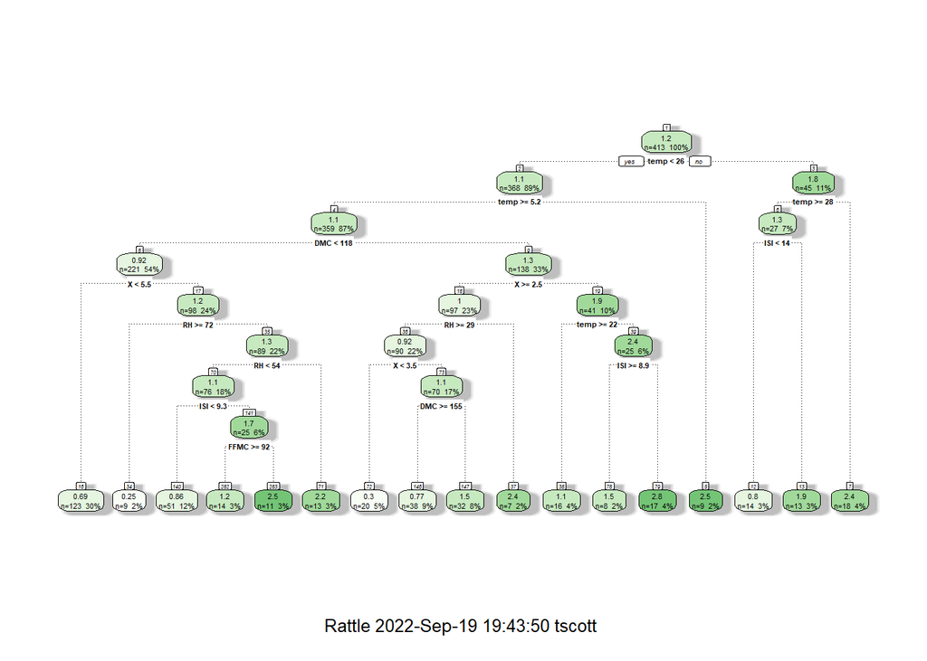

```r
fancyRpartPlot(myTree)
```

## Check predictions and RMSE

```r
# get predictions
predict_tree <- predict(myTree, newdata=testData, type='vector')

# compute RMSE
myRMSE(predict_tree, testData$logArea)
```

```
## [1] 1.44907
```

### This RMSE is actually worse than the multi-linear model

```r
# check how error and cp vary
# looks like it can't get any better
# (larger cp would likely produce a single node)
printcp(myTree)
```

```
##
## Regression tree:
## rpart(formula = logArea ~ . - area, data = trainingData, method = "anova")
##
## Variables actually used in tree construction:
## [1] DMC  FFMC ISI  RH   temp X
##
## Root node error: 816.48/413 = 1.977
##
## n= 413
##
##          CP nsplit rel error xerror     xstd
## 1  0.022462      0   1.00000 1.0081 0.077693
## 2  0.022363      1   0.97754 1.0504 0.079819
## 3  0.018939      2   0.95517 1.0731 0.081073
## 4  0.017636      5   0.89782 1.1269 0.088942
## 5  0.017626      6   0.88019 1.1343 0.089119
## 6  0.015334      7   0.86256 1.1862 0.089803
## 7  0.013836      8   0.84723 1.2203 0.091676
## 8  0.013535     11   0.80572 1.2318 0.092046
## 9  0.012193     12   0.79219 1.2508 0.093342
## 10 0.011842     13   0.77999 1.2627 0.093869
## 11 0.010875     14   0.76815 1.2556 0.093924
## 12 0.010096     15   0.75728 1.2486 0.094223
## 13 0.010000     16   0.74718 1.2510 0.092958
```

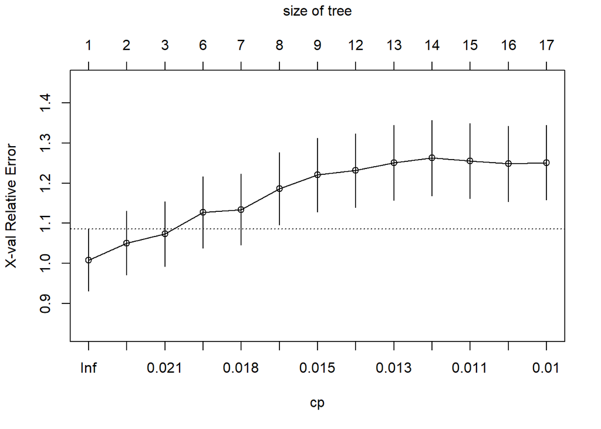

```r
plotcp(myTree)
```

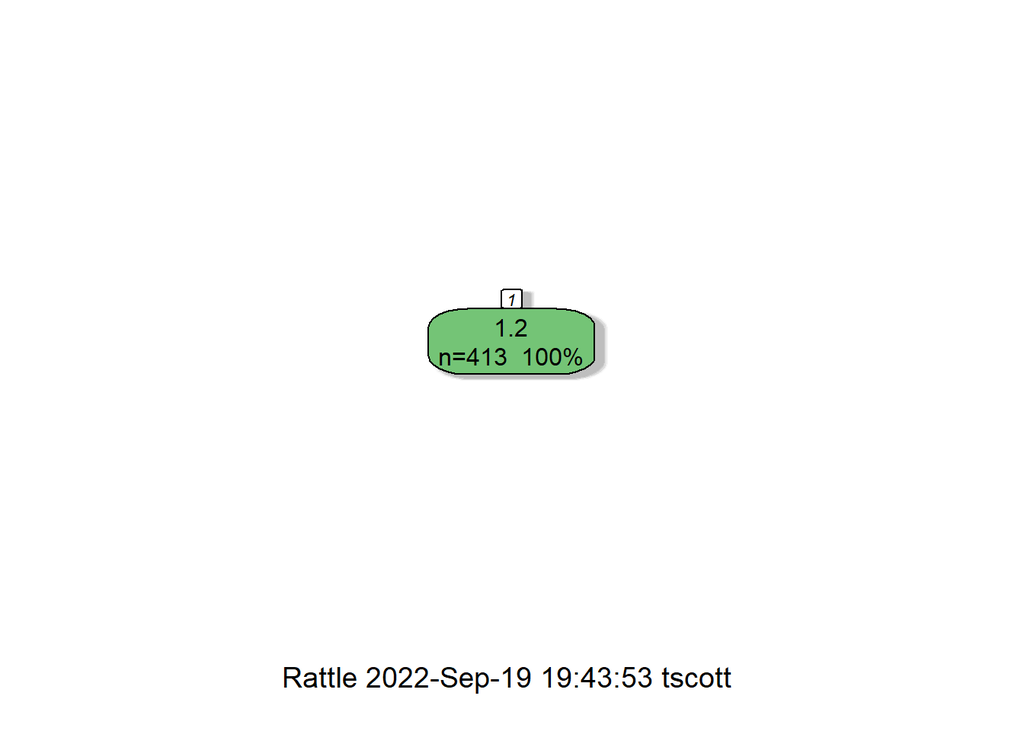

```r
# prune it with larger and smaller
prunedTreeMoreCP <- prune.rpart(myTree,cp=0.025)
fancyRpartPlot(prunedTreeMoreCP)
```

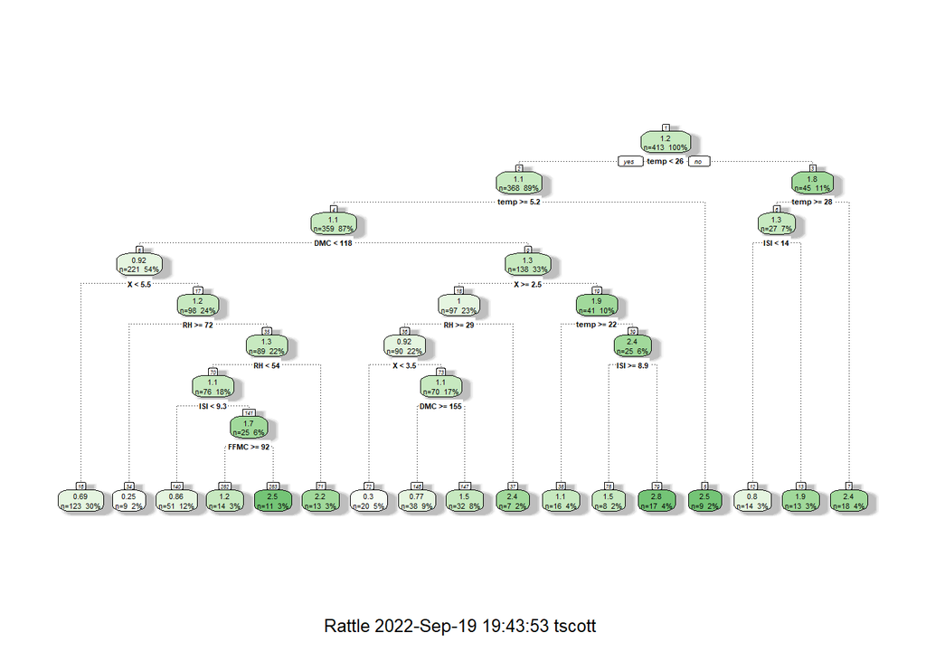

```r
prunedTreeLessCP <- prune.rpart(myTree, cp=0.005)
fancyRpartPlot(prunedTreeLessCP)
```

```r
predicted_tree_largeCP <- predict(prunedTreeMoreCP, testData)
predicted_tree_smallCP <- predict(prunedTreeLessCP, testData)
```